# Week 5: home assignment

Manuel Trombetta

2026-02-14

### Mixed-Effects Analysis of Visual Lexical Decision Times

# Task A - **Load Packages and dataset:**

```r
library(tidyverse)
library(lme4)
library(MuMIn)
library(tidyr)
library(broom)
library(ggeffects)
library(languageR)
```

look at the data:

```r
data <- lexdec
head(data)
```

```
##   Subject       RT Trial Sex NativeLanguage Correct PrevType PrevCorrect
## 1      A1 6.340359    23   F        English correct     word     correct
## 2      A1 6.308098    27   F        English correct  nonword     correct
## 3      A1 6.349139    29   F        English correct  nonword     correct
## 4      A1 6.186209    30   F        English correct     word     correct
## 5      A1 6.025866    32   F        English correct  nonword     correct
## 6      A1 6.180017    33   F        English correct     word     correct
##         Word Frequency FamilySize SynsetCount Length  Class FreqSingular
## 1        owl  4.859812  1.3862944   0.6931472      3 animal           54
## 2       mole  4.605170  1.0986123   1.9459101      4 animal           69
## 3     cherry  4.997212  0.6931472   1.6094379      6  plant           83
## 4       pear  4.727388  0.0000000   1.0986123      4  plant           44
## 5        dog  7.667626  3.1354942   2.0794415      3 animal         1233
## 6 blackberry  4.060443  0.6931472   1.3862944     10  plant           26
##   FreqPlural DerivEntropy Complex      rInfl meanRT SubjFreq meanSize
## 1         74       0.7912 simplex -0.3101549 6.3582     3.12   3.4758
## 2         30       0.6968 simplex  0.8145080 6.4150     2.40   2.9999
## 3         49       0.4754 simplex  0.5187938 6.3426     3.88   1.6278
## 4         68       0.0000 simplex -0.4274440 6.3353     4.52   1.9908
## 5        828       1.2129 simplex  0.3977961 6.2956     6.04   4.6429
## 6         31       0.3492 complex -0.1698990 6.3959     3.28   1.5831
##   meanWeight      BNCw      BNCc       BNCd BNCcRatio BNCdRatio
## 1     3.1806 12.057065  0.000000   6.175602  0.000000  0.512198
## 2     2.6112  5.738806  4.062251   2.850278  0.707856  0.496667
## 3     1.2081  5.716520  3.249801  12.588727  0.568493  2.202166
## 4     1.6114  2.050370  1.462410   7.363218  0.713242  3.591166
## 5     4.5167 74.838494 50.859385 241.561040  0.679589  3.227765
## 6     1.1365  1.270338  0.162490   1.187616  0.127911  0.934882
```

# Task B - **Filter the data:**

```r
data <- as_tibble(data) %>%
  filter(RT < 7, Correct == "correct")

# count rows:
nrow(data)
```

```
## [1] 1557
```

# Task C - **Creation of the mixed linear regression model:**

```r
data_lmer <- lmer(RT ~ Trial + Length +
                    (1|Subject) + # random intercept
                    (1|Word),
                  data = data,
                  REML = FALSE)
summary(data_lmer)
```

```
## Linear mixed model fit by maximum likelihood  ['lmerMod']
## Formula: RT ~ Trial + Length + (1 | Subject) + (1 | Word)
##    Data: data
##
##       AIC       BIC    logLik -2*log(L)  df.resid
##   -1280.6   -1248.5     646.3   -1292.6      1551
##
## Scaled residuals:
##     Min      1Q  Median      3Q     Max
## -2.3975 -0.6611 -0.1144  0.5174  4.5044
##
## Random effects:
##  Groups   Name        Variance Std.Dev.
##  Word     (Intercept) 0.003377 0.05811
##  Subject  (Intercept) 0.017773 0.13331
##  Residual             0.022554 0.15018
## Number of obs: 1557, groups:  Word, 79; Subject, 21
##
## Fixed effects:
##               Estimate Std. Error t value
## (Intercept)  6.282e+00  3.943e-02 159.330
## Trial       -1.838e-04  8.183e-05  -2.246
## Length       1.893e-02  4.079e-03   4.641
##
## Correlation of Fixed Effects:
##        (Intr) Trial
## Trial  -0.215
## Length -0.609 -0.005
```

We include random intercepts for Subject and Word because the data contain repeated measurements: *each subject responds to many words and each word is seen by many subjects*. Participants differ in their overall speed, and words differ in their difficulty.

Looking at the variance components, the variance for Subject (0.0177) is close to the residual variance (0.0225), indicating **substantial differences in baseline reaction times across participants**. In contrast, the variance for Word (0.0034) is much smaller relative to the residual variance, suggesting that variability across lexical items is present but less pronounced.

# Task D - **Significance testing of predictors**

```r
# model with no Trial:
model_noTrial <- lmer(RT ~ Length +
                        (1|Subject) + (1|Word),
                      data = data,
                      REML = FALSE)

anova(model_noTrial, data_lmer)
```

```
## Data: data
## Models:
## model_noTrial: RT ~ Length + (1 | Subject) + (1 | Word)
## data_lmer: RT ~ Trial + Length + (1 | Subject) + (1 | Word)
##               npar     AIC     BIC logLik -2*log(L)  Chisq Df Pr(>Chisq)
## model_noTrial    5 -1277.6 -1250.8 643.79   -1287.6
## data_lmer        6 -1280.6 -1248.5 646.30   -1292.6 5.0351  1    0.02484 *
## ---
## Signif. codes:  0 '***' 0.001 '**' 0.01 '*' 0.05 '.' 0.1 ' ' 1
```

```r
# model with no Length:
model_noLength <- lmer(RT ~ Trial +
                         (1|Subject) + (1|Word),
                       data = data,
                       REML = FALSE)

anova(model_noLength, data_lmer)
```

```
## Data: data
## Models:
## model_noLength: RT ~ Trial + (1 | Subject) + (1 | Word)
## data_lmer: RT ~ Trial + Length + (1 | Subject) + (1 | Word)
##                npar     AIC     BIC logLik -2*log(L)  Chisq Df Pr(>Chisq)
## model_noLength    5 -1263.6 -1236.8 636.78   -1273.6
## data_lmer         6 -1280.6 -1248.5 646.30   -1292.6 19.043  1  1.278e-05 ***
## ---
## Signif. codes:  0 '***' 0.001 '**' 0.01 '*' 0.05 '.' 0.1 ' ' 1
```

The **chi-square statistic** indicates how much the model improves when a predictor is added, the **degrees of freedom** represent the number of added parameters, and the **p-value** shows whether this improvement is statistically significant.

Adding Trial significantly improves the model (Chisq = 5.03, df = 1, p = .025), showing that reaction times change during the experiment. Adding Length improves the model even more (Chisq = 19.04, df = 1, p < .001), indicating that longer words lead to longer reaction times. Both null hypotheses are rejected.

# Task E - **Subject variation in reaction time across Trials**

Add random slope:

```r
data_lmer2 <- lmer(RT ~ Trial + Length +
                    (1 + Trial|Subject) + # random slope
                    (1|Word),
                  data = data,
                  REML = FALSE)
summary(data_lmer2)
```

```
## Linear mixed model fit by maximum likelihood  ['lmerMod']
## Formula: RT ~ Trial + Length + (1 + Trial | Subject) + (1 | Word)
##    Data: data
##
##       AIC       BIC    logLik -2*log(L)  df.resid
##   -1308.3   -1265.5     662.1   -1324.3      1549
##
## Scaled residuals:
##     Min      1Q  Median      3Q     Max
## -2.3972 -0.6531 -0.1028  0.5026  4.5483
##
## Random effects:
##  Groups   Name        Variance  Std.Dev.  Corr
##  Word     (Intercept) 2.732e-03 0.0522712
##  Subject  (Intercept) 3.531e-02 0.1879185
##           Trial       4.663e-07 0.0006828 -0.71
##  Residual             2.178e-02 0.1475825
## Number of obs: 1557, groups:  Word, 79; Subject, 21
##
## Fixed effects:
##               Estimate Std. Error t value
## (Intercept)  6.2850303  0.0478830 131.258
## Trial       -0.0002037  0.0001695  -1.202
## Length       0.0187970  0.0037643   4.994
##
## Correlation of Fixed Effects:
##        (Intr) Trial
## Trial  -0.614
## Length -0.462 -0.003
## optimizer (nloptwrap) convergence code: 0 (OK)
## Model failed to converge with max|grad| = 2.15225 (tol = 0.002, component 1)
##   See ?lme4::convergence and ?lme4::troubleshooting.
## Model is nearly unidentifiable: very large eigenvalue
##  - Rescale variables?
```

Create predictions for Subject:

```r
mymodel_pred <- predict_response(
  data_lmer2,
  terms = c("Trial", "Subject"),
  type = "random")
```

Create the plot:

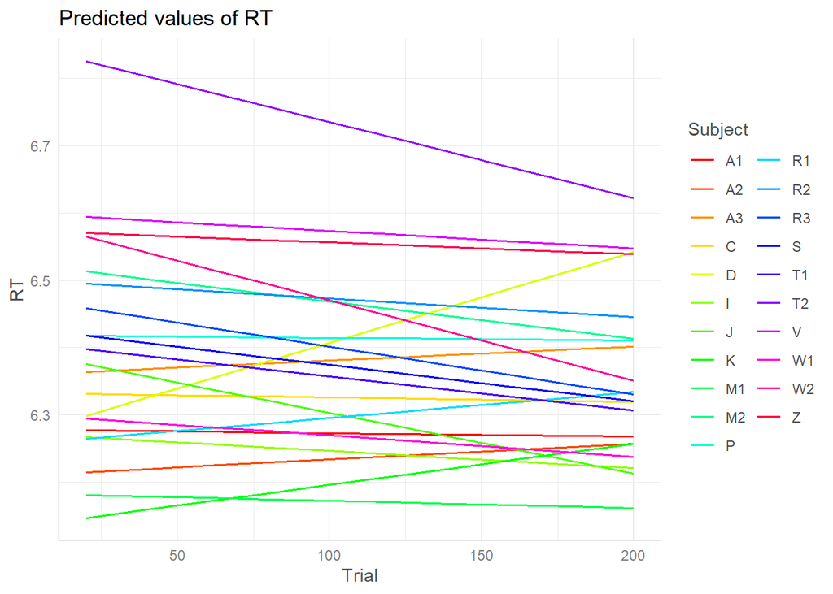

```r
plot(mymodel_pred, show_ci = FALSE) +
  scale_color_manual(values = rainbow(21))
```

**Interpretation**:

Most subjects show decreasing predicted reaction times across trials, suggesting a practice effect. A few participants display flatter or slightly increasing trends, indicating individual variability and possible fatigue.